# PCFL: Week 8 wrap-up

### Last week’s games

| Away | Away points | Home | Home points |
| --- | --- | --- | --- |
| First Timers The FTs | 88.54 | Georgia Peanuts | 183.92 |
| KC Gophers | 105.76 | Jumpin’ Jaheims | 83.56 |
| Athens Team Sasquatch | 95.02 | Southern Sharks | 95.94 |
| Middle Earth Hangry Hobbits | 96.12 | Captain Clairvoyant | 106.44 |
| The G.O.A.T. | 59.00 | Pigskin on the Gridiron | 102.76 |

A bit of a low scoring week this week (aside from one outlier!). We had both extremes, though. The Peanuts shelled the First Timers, winning by nearly 100 points. At the other end, the Sharks nibbled just enough of Team Sasquatch to secure a victory against the league leaders. In our family game of the week, Richard scored a convincing win, as Jacob’s G.O.A.T. struggled to dig out of an offensive slump. Christine’s Gophers also dug out the Jaheims, winning by over 20 points.

Obligatory reminder: you should make sure to check your bye weeks and also whether your stars are active at gametime.

#### Best performing players

Here’s last week’s **10 best performing players.**

| Player | Points | Team |
| --- | --- | --- |
| Dalvin Cook | 48.60 | Georgia Peanuts |
| Patrick Mahomes | 36.64 | First Timers The FTs |
| DK Metcalf | 35.10 | Captain Clairvoyant |
| Russell Wilson | 28.74 | Southern Sharks |
| Davante Adams | 26.80 | Georgia Peanuts |
| Robert Woods | 24.90 | Pigskin on the Gridiron |
| Tyreek Hill | 24.80 | KC Gophers |
| Aaron Rodgers | 22.54 | Captain Clairvoyant |
| Matthew Stafford | 22.44 | Pigskin on the Gridiron |
| Giovani Bernard | 21.30 | Southern Sharks |

Dalvin Cook (along with Davante Adams) powered the Peanuts’ dominant performance this week. Some other usual suspects at quarterback also make the list: Mahomes, Wilson, Rodgers, and Stafford. DK Metcalf also had a standout week for Brian’s squad.

#### Best addition and worst starters

There were 13 players added last week. Which was the **best new addition**?

| Date added | Name | Points | Team |
| --- | --- | --- | --- |
| 2020-10-30 | Giovani Bernard | 21.30 | Southern Sharks |
| 2020-10-29 | Brandon Aiyuk | 19.10 | KC Gophers |
| 2020-10-28 | Saints D/ST | 7.00 | Middle Earth Hangry Hobbits |
| 2020-10-30 | Brandon McManus | 7.00 | Pigskin on the Gridiron |
| 2020-10-28 | Tua Tagovailoa | 5.72 | Georgia Peanuts |
| 2020-10-28 | Joey Slye | 5.00 | Jumpin’ Jaheims |
| 2020-10-28 | Justin Jefferson | 4.10 | Georgia Peanuts |
| 2020-10-31 | Jason Sanders | 4.00 | Captain Clairvoyant |
| 2020-10-30 | Patriots D/ST | 3.00 | Captain Clairvoyant |
| 2020-10-29 | A.J. Green | 2.90 | The G.O.A.T. |
| 2020-10-28 | Chargers D/ST | 2.00 | Southern Sharks |
| 2020-11-01 | Dallas Goedert | 2.00 | Athens Team Sasquatch |
| 2020-10-28 | Carlos Hyde | 0.00 | Georgia Peanuts |

While there were a lot of pickups last week, they didn’t have a whole lot of payoff. The exceptions were Giovani Bernard, the veteran who provided a nice boost for Sarah. Brandon Aiyuk was another nice pickup for the Gophers.

Who won the **best scoring bench** award last week?

| Team | Points |
| --- | --- |
| Athens Team Sasquatch | 79.50 |
| KC Gophers | 71.68 |
| Georgia Peanuts | 61.26 |
| Captain Clairvoyant | 60.70 |
| Southern Sharks | 56.20 |
| Pigskin on the Gridiron | 49.74 |
| Jumpin’ Jaheims | 40.90 |
| The G.O.A.T. | 31.85 |
| First Timers The FTs | 30.52 |
| Middle Earth Hangry Hobbits | 18.60 |

### League standings and season stats

Here’s a look at our current standings

| Team | Division | W | L | Points scored | Points allowed | Points rank | Playoff rank |
| --- | --- | --- | --- | --- | --- | --- | --- |
| Captain Clairvoyant | Grits | 6 | 2 | 951.43 | 867.46 | 2 | 1 |
| Athens Team Sasquatch | Grits | 6 | 2 | 912.39 | 882.64 | 4 | 2 |
| Georgia Peanuts | Hot Dish | 5 | 3 | 1034.98 | 889.11 | 1 | 3 |
| Southern Sharks | Hot Dish | 5 | 3 | 898.86 | 855.13 | 6 | 4 |
| The G.O.A.T. | Grits | 4 | 4 | 883.61 | 950.48 | 7 | 5 |
| KC Gophers | Hot Dish | 4 | 4 | 825.75 | 852.17 | 9 | 6 |
| First Timers The FTs | Hot Dish | 3 | 5 | 924.32 | 984.11 | 3 | 7 |
| Pigskin on the Gridiron | Grits | 3 | 5 | 849.66 | 895.84 | 8 | 8 |
| Middle Earth Hangry Hobbits | Hot Dish | 2 | 6 | 901.00 | 925.05 | 5 | 9 |
| Jumpin’ Jaheims | Grits | 2 | 6 | 822.48 | 902.49 | 10 | 10 |

Here’s our current awards leaders from these standings:

- Yellow shirt (most points): Georgia Peanuts
- D-FENCE (least points allowed): KC Gophers
- Tough luck (points rank - playoff rank): Hangry Hobbits (5th in points, 9th in the standings) and the First Timers (3rd and 7th)
- Lucky ducks (playoff rank - points rank): KC Gophers (9th in points, 6th in the standings)

Here’s a list of the **top five scoring performances** so far this season.

| Team | Week | Points scored | Result |
| --- | --- | --- | --- |
| Georgia Peanuts | 8 | 183.92 | W |
| First Timers The FTs | 2 | 171.28 | W |
| Georgia Peanuts | 7 | 163.68 | W |
| Captain Clairvoyant | 3 | 150.32 | W |
| Middle Earth Hangry Hobbits | 5 | 142.36 | W |

The Peanuts roasted the competition last week.

Lastly, here’s a look at the **points trendline** for each team.

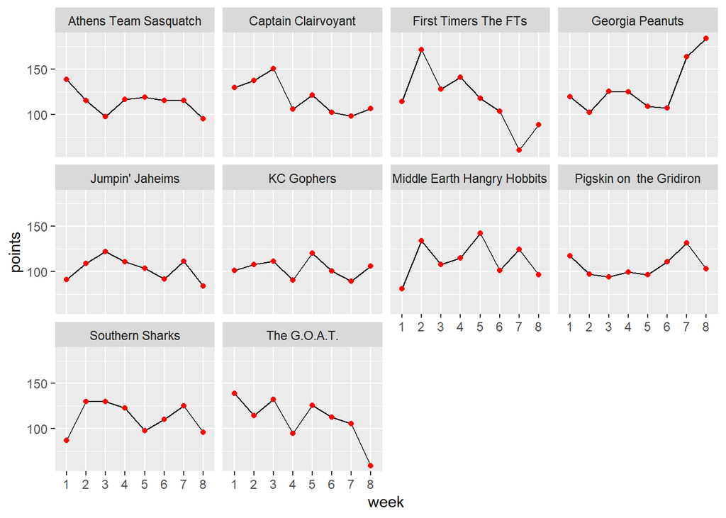

## Next week’s games

Here’s a quick summary of next week’s matchups:

| week | away_team | away_points | home_team | home_points | range |
| --- | --- | --- | --- | --- | --- |
| 9 | Georgia Peanuts | 1034.98 | KC Gophers | 825.75 | 209.23 |
| 9 | First Timers The FTs | 924.32 | Athens Team Sasquatch | 912.39 | 11.93 |
| 9 | Pigskin on the Gridiron | 849.66 | Jumpin’ Jaheims | 822.48 | 27.18 |
| 9 | The G.O.A.T. | 883.61 | Middle Earth Hangry Hobbits | 901.00 | 17.39 |
| 9 | Captain Clairvoyant | 951.43 | Southern Sharks | 898.86 | 52.57 |